# R Notebook

The file project_management.csv contains data sampled from the recent work schedule of a small construction company. Column estimated_length contains the estimated length of a building job in days, while column actual_length contains the actual recorded length of the job in days.

We are interested in determining the accuracy of the job estimations made by the company using simple linear regression, so we will eventually want to run a simple linear regression using actual_length as the dependent variable, and estimated_length as the independent variable.

```r
library(broom)
```

# Load the data into a dataframe *project*

# Plot the data, taking estimated_length as the independent variable and actual_length as the dependent variable.

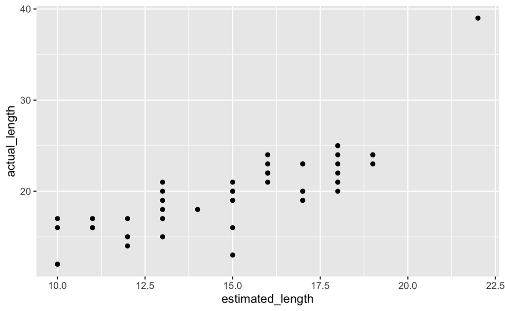

# Calculate the correlation coefficient of estimated_length and actual_length and interpret the value you obtain.

| cor(estimated_length, actual_length) |
| --- |
| 0.8046597 |

# Perform a simple linear regression using actual_length as the dependent variable, and estimated_length as the independent variable. Save the model object to a variable.

# Interpret the regression coefficient of estimated_length (i.e. slope, gradient) you obtain from the model. How do you interpret the r2 value reported by the model?

| r.squared | adj.r.squared | sigma | statistic | p.value | df | logLik | AIC | BIC | deviance | df.residual | nobs |
| --- | --- | --- | --- | --- | --- | --- | --- | --- | --- | --- | --- |
| 0.6474772 | 0.640133 | 2.606163 | 88.16142 | 1.911284e-12 | 1 | -117.8203 | 241.6407 | 247.3767 | 326.0201 | 48 | 50 |

# Is the relationship statistically significant? Remember, to assess this you need to check the p-value of the regression coefficient (or slope/gradient). But you should first check the regression diagnostic plots to see if the p-value will be reliable (don’t worry about any outlier points you see in the diagnostic plots, we’ll return to them in the extension).

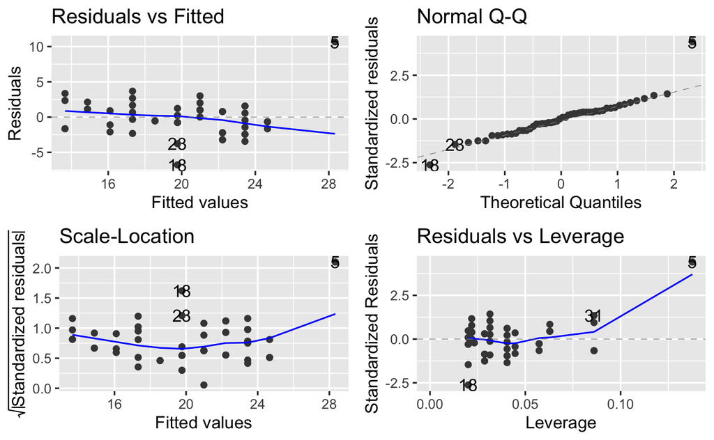

| term | estimate | std.error | statistic | p.value |
| --- | --- | --- | --- | --- |
| (Intercept) | 1.416379 | 2.0069491 | 0.7057375 | 4.837627e-01 |
| estimated_length | 1.223489 | 0.1303049 | 9.3894314 | 1.911284e-12 |

```r
project_model %>%
  autoplot()

project_model %>%
  tidy()
```

# Return to your plot from earlier, and now label the data points with their row number in the data frame using geom_text() [Hint - you can pass aes(label=1:nrow(project)) to this layer to generate row index labels]

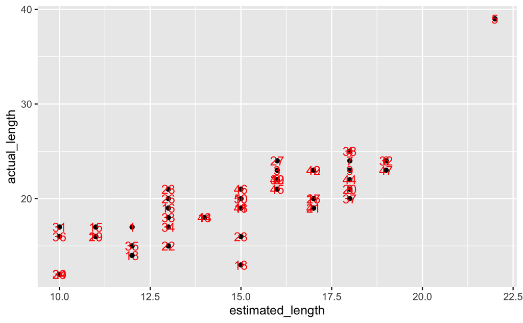

## Identify by eye any points you think might be outliers and note their labels.

*5* maybe *18* , 31

## Further split your outliers into those you think are ‘influential’ or ‘non-influential’ based on a visual assessment of their leverage.

Influential *5* Non-influential *18*

# Use your model object from earlier and confirm your visual assessment of which points are ‘influential’ or ‘non-influential’ outliers based on Cook’s distance. You can get a useful plot of Cook’s distance by passing argument which = 4 to autoplot(). Or try the base R plot() function for comparison [e.g. plot(model); you can also use par(mfrow = c(2,2)) just before the plot() command to get a nice two-by-two display]!

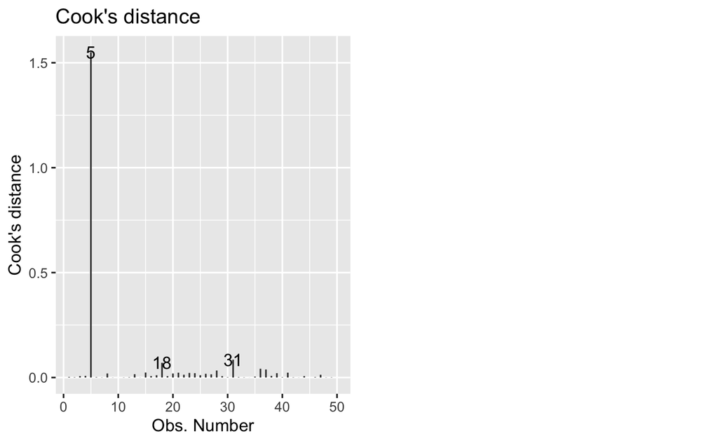